# DS 202 - Homework #5

10-18-2022

## Flying etiquette

FiveThirtyEight is a website founded by Statistician and writer Nate Silver to publish results from opinion poll analysis, politics, economics, and sports blogging. One of the featured articles considers [flying etiquette](https://fivethirtyeight.com/features/airplane-etiquette-recline-seat/). This article is based on data collected by FiveThirtyEight and publicly available on github. Use the code below to read in the data from the survey:

```r
fly <- read.csv("https://raw.githubusercontent.com/fivethirtyeight/data/master/flying-etiquette-survey/flying-etiquette.csv")
```

The following couple of lines of code provide a bit of cleanup of the demographic information by reaordering the levels of the corresponding factor variables. Run this code in your session.

```r
fly$Age <- factor(fly$Age, levels=c("18-29", "30-44", "45-60", "> 60", ""))
fly$Household.Income <- factor(fly$Household.Income, levels = c("$0 - $24,999","$25,000 - $49,999", "$50,000 - $99,999", "$100,000 - $149,999", "150000", ""))
fly$Education <- factor(fly$Education, levels = c("Less than high school degree", "High school degree", "Some college or Associate degree", "Bachelor degree",  "Graduate degree", ""))
```

1. Download the RMarkdown file with these homework instructions to use as a template for your work. Make sure to replace “Your Name” in the YAML with your name.
2. Some people do not travel often by plane. Provide a (visual) breakdown of travel frequency (use variable `How.often.do.you.travel.by.plane.`). Reorder the levels in the variable by travel frequency from least frequent travel to most frequent. Draw a barchart of travel frequency and comment on it. Exclude all respondents who never fly from the remainder of the analysis. How many records does the data set have now?

```r
library(ggplot2)
library(forcats)
library(dplyr)
#I used this to know the outputs to reorder
unique(fly$How.often.do.you.travel.by.plane.)
```

```
## [1] "Once a year or less"   "Once a month or less"  "Never"
## [4] "A few times per week"  "Every day"             "A few times per month"
```

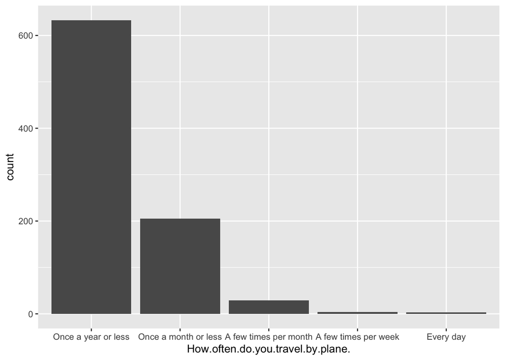

```r
#Making How.often.do.you.travel.by.plane into a factor variable
fly$How.often.do.you.travel.by.plane.<- factor(
    fly$How.often.do.you.travel.by.plane)

#Re-ordering the factor
fly$How.often.do.you.travel.by.plane.<- factor(fly$How.often.do.you.travel.by.plane., levels = c("Once a year or less", "Once a month or less", "A few times per month", "A few times per week", "Every day"))

#Taking out never values
fly2<-fly%>%
  filter(How.often.do.you.travel.by.plane. != "Never")

#Plotting the bar chart
fly2%>%
  ggplot(aes(x = How.often.do.you.travel.by.plane.)) + geom_bar()
```

```r
#Seeing how many values are left
length(fly2$How.often.do.you.travel.by.plane.)
```

```
## [1] 874
```

This barchart shows that a majority of people fly once a year or less (>600 people). Fewer people fly once a month or less (~200), around 25 people fly a few times per month, and extremely few people fly a few times per week or every day. This data set now includes 874 people, all of whom have flown in a plane before.

3. In the demographic variables (`Education`, `Age`, and `Houshold.Income`), replace all occurrences of the empty string “” by a missing value `NA`. How many responses in each variable do not have any missing values? How many responses have no missing values in any of the three variables? (Hint: think of the function `is.na`)

   ```r
   #Setting "" to NA
   fly2$Education[fly2$Education == ""]<- NA
   fly2$Age[fly2$Age == ""] <- NA
   fly2$Household.Income[fly2$Household.Income == ""] <- NA

   #Find sum or non-NA values for all three variables individually
   valuesEducation = sum(!is.na(fly2$Education))
   valuesEducation
   ```

   ```
   ## [1] 837
   ```

   ```r
   valuesAge = sum(!is.na(fly2$Age))
   valuesAge
   ```

   ```
   ## [1] 843
   ```

   ```r
   valuesIncome = sum(!is.na(fly2$Household.Income))
   valuesIncome
   ```

   ```
   ## [1] 698
   ```

   ```r
   #Finding how many values are not NA across all 3 variables
   fly3 <-fly2%>%
     filter(!is.na(Age), !is.na(Education), !is.na(Household.Income))

   count(fly3)
   ```

   ```
   ##     n
   ## 1 696
   ```

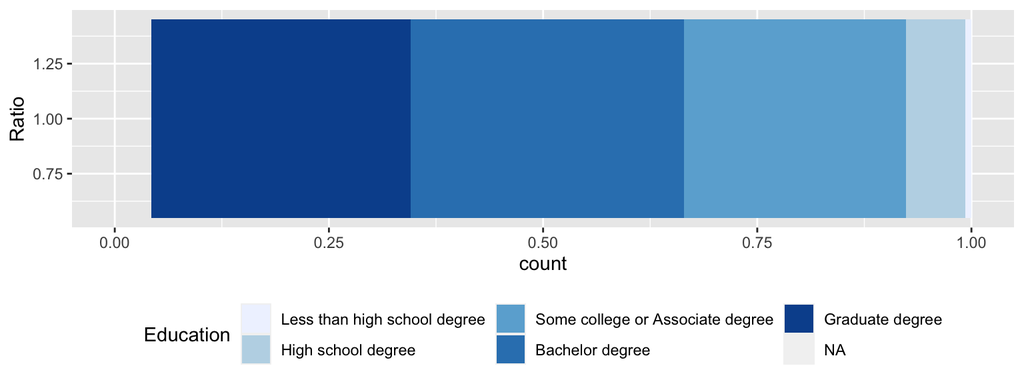

```r
library(ggplot2)
fly$Education = with(fly, factor(Education, levels = rev(levels(Education))))

ggplot(data = fly2, aes(x = 1)) +
  geom_bar(aes(fill=Education), position="fill") +
  coord_flip() +
  theme(legend.position="bottom") +
  scale_fill_brewer() +
  xlab("Ratio")
```

The purpose or goal of this graph seems to be showing a frequency count or ratio of all of the different education levels in the data set, allowing the user to get a better understanding of how people fall into each category. This could be used to change business strategies for airlines to cater to audiences. The main problem with this graph is that it is difficult to tell what exact ratio each level of education has. A vertical bar graph would be much better at showing this data. Furthermore, because there are NA values that have not been taken out of the data, it does not appear to equal 100% which also makes it difficult to interpret.

5. Rename the variable `In.general..is.itrude.to.bring.a.baby.on.a.plane.` to `baby.on.plane.`. How many levels does the variable `baby.on.plane` have, and what are these levels? Rename the level labeled “” to “Not answered”. Bring the levels of `baby.on.plane` in an order from least rude to most rude. Put the level “Not answered” last. Draw a barchart of variable `baby.on.plane`. Interpret the result. (This question is very similar to question 2, but preps the data for the next question)

   ```r
   #Renaming the column
   colnames(fly2)[colnames(fly2) == "In.general..is.itrude.to.bring.a.baby.on.a.plane."] = "baby.on.plane"
   colnames(fly2)
   ```

   ```
   ##  [1] "RespondentID"
   ##  [2] "How.often.do.you.travel.by.plane."
   ##  [3] "Do.you.ever.recline.your.seat.when.you.fly."
   ##  [4] "How.tall.are.you."
   ##  [5] "Do.you.have.any.children.under.18."
   ##  [6] "In.a.row.of.three.seats..who.should.get.to.use.the.two.arm.rests."
   ##  [7] "In.a.row.of.two.seats..who.should.get.to.use.the.middle.arm.rest."
   ##  [8] "Who.should.have.control.over.the.window.shade."
   ##  [9] "Is.itrude.to.move.to.an.unsold.seat.on.a.plane."
   ## [10] "Generally.speaking..is.it.rude.to.say.more.than.a.few.words.tothe.stranger.sitting.next.to.you.on.a.plane."
   ## [11] "On.a.6.hour.flight.from.NYC.to.LA..how.many.times.is.it.acceptable.to.get.up.if.you.re.not.in.an.aisle.seat."
   ## [12] "Under.normal.circumstances..does.a.person.who.reclines.their.seat.during.a.flight.have.any.obligation.to.the.person.sitting.behind.them."
   ## [13] "Is.itrude.to.recline.your.seat.on.a.plane."
   ## [14] "Given.the.opportunity..would.you.eliminate.the.possibility.of.reclining.seats.on.planes.entirely."
   ## [15] "Is.it.rude.to.ask.someone.to.switch.seats.with.you.in.order.to.be.closer.to.friends."
   ## [16] "Is.itrude.to.ask.someone.to.switch.seats.with.you.in.order.to.be.closer.to.family."
   ## [17] "Is.it.rude.to.wake.a.passenger.up.if.you.are.trying.to.go.to.the.bathroom."
   ## [18] "Is.itrude.to.wake.a.passenger.up.if.you.are.trying.to.walk.around."
   ## [19] "baby.on.plane"
   ## [20] "In.general..is.it.rude.to.knowingly.bring.unruly.children.on.a.plane."
   ## [21] "Have.you.ever.used.personal.electronics.during.take.off.or.landing.in.violation.of.a.flight.attendant.s.direction."
   ## [22] "Have.you.ever.smoked.a.cigarette.in.an.airplane.bathroom.when.it.was.against.the.rules."
   ## [23] "Gender"
   ## [24] "Age"
   ## [25] "Household.Income"
   ## [26] "Education"
   ## [27] "Location..Census.Region."
   ```

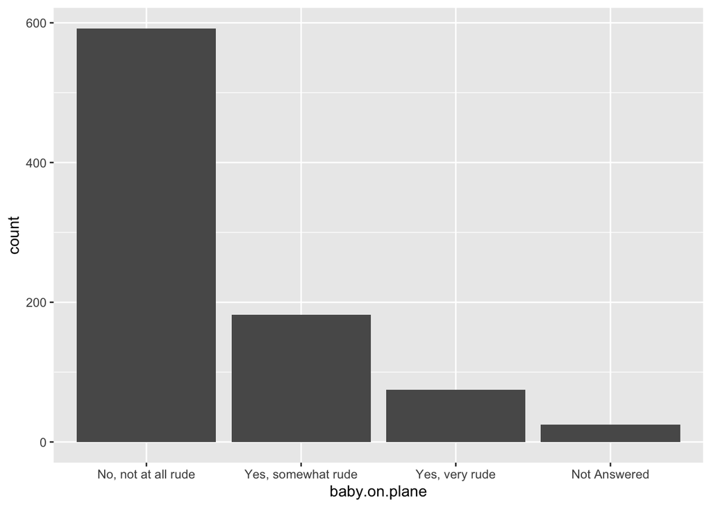

   ```r
   #Resetting "" to Not Answered
   fly2$baby.on.plane[fly2$baby.on.plane == ""] <- "Not Answered"

   #Re-ordering the factor
   fly2$baby.on.plane <- factor(fly2$baby.on.plane, levels = c("No, not at all rude", "Yes, somewhat rude", "Yes, very rude", "Not Answered"))
   ggplot(data = fly2, aes(x = baby.on.plane))+geom_bar()
   ```

   According to the data, most people do not find it rude to bring a baby on a plane, with nearly 600 respondents feeling that way. The next largest category was people who found it somewhat rude, with about 170 respondents saying this, much less than people who did not find it rude. Very few people, about 70, thought it was very rude to bring a baby on the plane, and a very small number of people did not answer this question.
6. Investigate the relationship between gender and the variables `Do.you.have.any.children.under.18.` and `baby.on.plane`. How is the attitude towards babies on planes shaped by gender and own children under 18? Find a plot that summarises your findings (use `ggplot2`).

```r
#Changing "" to Not Answered
fly2$Do.you.have.any.children.under.18.[fly2$Do.you.have.any.children.under.18. == ""] <- "Not Answered"

#A Chi-Squared test between children under 18 and baby on plane
#Shows these two variables are dependent
chisq.test(fly2$Do.you.have.any.children.under.18., fly2$baby.on.plane)
```

```
##
##  Pearson's Chi-squared test
##
## data:  fly2$Do.you.have.any.children.under.18. and fly2$baby.on.plane
## X-squared = 564.97, df = 6, p-value < 2.2e-16
```

```r
#A Chi-Squared test between children until 18 and baby on plane
#Shows these two variables are dependent
chisq.test(fly2$Do.you.have.any.children.under.18., fly2$Gender)
```

```
##
##  Pearson's Chi-squared test
##
## data:  fly2$Do.you.have.any.children.under.18. and fly2$Gender
## X-squared = 432.15, df = 4, p-value < 2.2e-16
```

```r
#Frequency table for males on their views for babies on planes
fly2%>%
  filter(Gender == "Male")%>%
  group_by(baby.on.plane)%>%
  summarise(n = n()) %>%
  mutate(Freq = n/sum(n))
```

```
## # A tibble: 3 × 3
##   baby.on.plane           n  Freq
##   <fct>               <int> <dbl>
## 1 No, not at all rude   249 0.621
## 2 Yes, somewhat rude    105 0.262
## 3 Yes, very rude         47 0.117
```

```r
#Frequency table for females on their views for babies on planes
fly2%>%
  filter(Gender == "Female")%>%
  group_by(baby.on.plane)%>%
  summarise(n = n()) %>%
  mutate(Freq = n/sum(n))
```

```
## # A tibble: 3 × 3
##   baby.on.plane           n   Freq
##   <fct>               <int>  <dbl>
## 1 No, not at all rude   338 0.765
## 2 Yes, somewhat rude     76 0.172
## 3 Yes, very rude         28 0.0633
```

```r
#Frequency table for people without children under 18 on their views for babies on planes
fly2%>%
  filter(Do.you.have.any.children.under.18.== "No")%>%
  group_by(baby.on.plane)%>%
  summarise(n = n()) %>%
  mutate(Freq = n/sum(n))
```

```
## # A tibble: 4 × 3
##   baby.on.plane           n    Freq
##   <fct>               <int>   <dbl>
## 1 No, not at all rude   432 0.653
## 2 Yes, somewhat rude    158 0.239
## 3 Yes, very rude         67 0.101
## 4 Not Answered            5 0.00755
```

```r
#Frequency table for people will children under 18 on their views for babies on planes
fly2%>%
  filter(Do.you.have.any.children.under.18. == "Yes")%>%
  group_by(baby.on.plane)%>%
  summarise(n = n()) %>%
  mutate(Freq = n/sum(n))
```

```
## # A tibble: 4 × 3
##   baby.on.plane           n    Freq
##   <fct>               <int>   <dbl>
## 1 No, not at all rude   158 0.836
## 2 Yes, somewhat rude     23 0.122
## 3 Yes, very rude          7 0.0370
## 4 Not Answered            1 0.00529
```

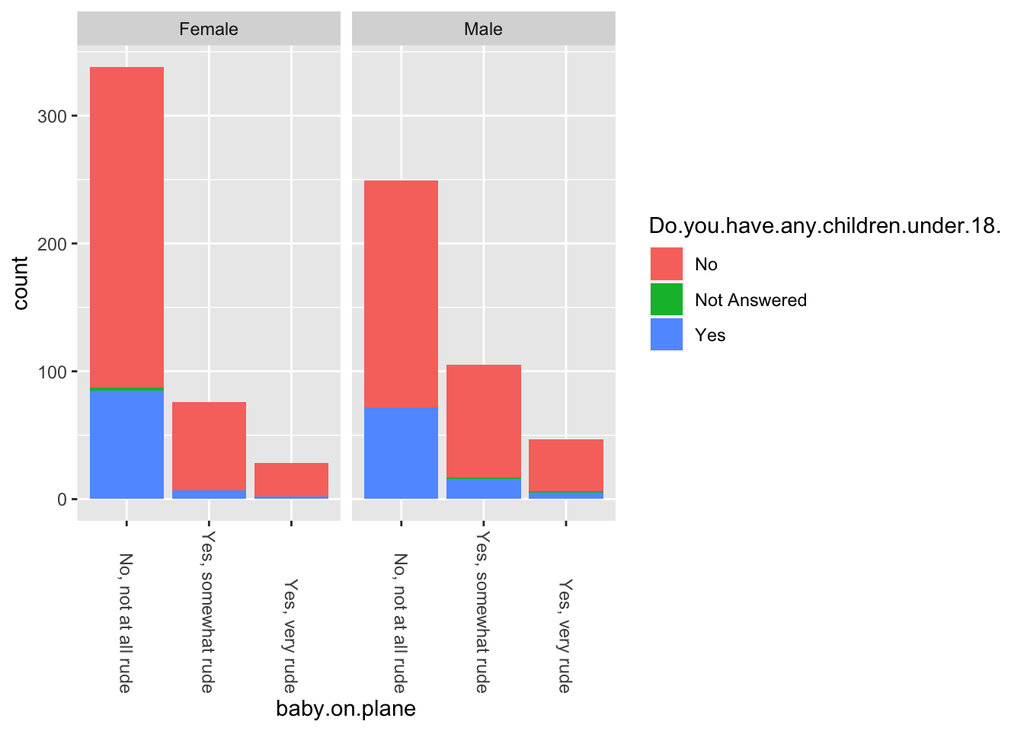

```r
#A bar chart for both males and females showing the relationship between having children under 18 and views on babies on the plane
fly2%>%
  filter(Gender %in% c("Male", "Female"))%>%
  ggplot(aes(x = baby.on.plane, fill = Do.you.have.any.children.under.18.)) +
  geom_bar() + facet_wrap(~Gender) +  theme(axis.text.x = element_text(angle=-90, vjust=.5, hjust=1))
```

From the results of the Chi-Squared test and the frequency tables, it is clear that whether or not someone has a child under 18 and whether someone is male or female has an affect on whether or not they think having a baby on the plane is rude. Males are more likely to say it is very rude to have a baby on the plane and less likely to say it is not rude at all when compared to females. Similarly, people who have children under 18 are more likely to say that having a baby on the plane is not rude at all and less likely to say having a baby on the plane is very rude when compared to those who do not have a child under 18. Overall, however, most people do not think it is rude to have a baby on the plane, regardless or gender or if they have a child.

For the submission: submit your solution in an R Markdown file and (just for insurance) submit the corresponding html/word file with it.